# Amas de Casa en la Economía Popular

Ariel Salgado

2023-03-31

```r
# Cargamos dataset y paquete de graficación
library(tidyverse)
load('base_ep.RData')
```

# Definición del grupo

Para construir nuestro grupo de interés, tomamos el último año y trimestre para el cual disponemos de información sobre pobreza. Luego, identificamos a personas EP como aquellas que son cuentapropistas no profesionales ó trabajadores familiares sin remuneración. Luego, generamos dos clasificaciones para identificar a una persona como “en familia EP”. Si el JEFE de su familia es EP, decimos que la persona es EPJ. Si alguien en su familia es EP (cualquiera, jefe o no), decimos que la persona es EPA. Filtramos la base para quedarnos con la población de interés: personas que hayan declarado como su cateogría de inactividad “AMA DE CASA” (sean del género que sean).

```r
df <- individual_03.hoy %>%
  filter(!is.na(situacion)) %>%
  filter(YEAR == max(YEAR)) %>%
  filter(TRIMESTER == max(TRIMESTER)) %>%
  mutate(ES_EP = ES_CUENTAPROPISTA_NO_PROFESIONAL | ES_TFSR) %>%
  group_by(CODUSU,NRO_HOGAR) %>%
  mutate(ES_EP_JEFE = ES_EP[ROL_HOGAR == 'JEFE']) %>%
  mutate(ES_EP_ANY = any(ES_EP)) %>%
  filter(CATEGORIA_INACTIVO == 'AMA DE CASA')
```

Aquí se puede explorar un poco la base

```r
df %>%
  arrange(CODUSU,NRO_HOGAR)
```

```
## # A tibble: 2,609 × 48
## # Groups:   CODUSU, NRO_HOGAR [2,442]
##     YEAR TRIMESTER REGION    AGLOMERADO  CODUSU  NRO_HOGAR ROL_HOGAR SEXO   EDAD
##    <dbl>     <dbl> <chr>     <chr>       <chr>       <dbl> <chr>     <chr> <dbl>
##  1  2022         1 GBA       PARTIDOS G… TQRMNO…         1 CONYUGE   VARON    57
##  2  2022         1 GBA       PARTIDOS G… TQRMNO…         1 HIJE      MUJER    18
##  3  2022         1 NOA       GRAN SALTA  TQRMNO…         1 CONYUGE   MUJER    40
##  4  2022         1 PAMPEANA  RIO CUARTO  TQRMNO…         1 CONYUGE   MUJER    34
##  5  2022         1 PAMPEANA  GRAN ROSAR… TQRMNO…         1 HIJE      MUJER    24
##  6  2022         1 PAMPEANA  GRAN ROSAR… TQRMNO…         1 HIJE      MUJER    22
##  7  2022         1 PAMPEANA  GRAN ROSAR… TQRMNO…         1 HIJE      MUJER    19
##  8  2022         1 PATAGONIA RAWSON - T… TQRMNO…         1 CONYUGE   MUJER    41
##  9  2022         1 PATAGONIA NEUQUEN - … TQRMNO…         1 CONYUGE   MUJER    37
## 10  2022         1 PAMPEANA  GRAN LA PL… TQRMNO…         1 HIJE      VARON    31
## # … with 2,599 more rows, and 39 more variables: ESTADO <chr>,
## #   CATEGORIA_OCUPACION <chr>, CATEGORIA_INACTIVO <chr>, PONDERA <dbl>,
## #   TIPO_OCUPACION <dbl>, REGISTRACION <dbl>, APORTE_PROPIO <dbl>,
## #   SERVICIO_DOMESTICO <dbl>, TOTAL_CASAS <dbl>, CODIGO_OCUPACION <chr>,
## #   TOTAL_INGRESO_INDIVIDUAL <dbl>, EX_SERVICIO_DOMESTICO <dbl>,
## #   EX_TIPO_OCUPACION <dbl>, INGRESOS_OCUP_PPAL <dbl>,
## #   INGRESO_JUBILACION <dbl>, INGRESO_AYUDA_SOCIAL <dbl>, …
```

# Análisis general de las personas que son amas de casa

Aquí van algunos gráficos descriptivos de la basa de personas AMA de CASA

##### División por género

```r
df %>%
  group_by(SEXO) %>%
  summarise('N' = sum(PONDIH)) %>%
  mutate('f' = N/sum(N))
```

```
## # A tibble: 2 × 3
##   SEXO        N     f
##   <chr>   <dbl> <dbl>
## 1 MUJER 1608656 0.848
## 2 VARON  289119 0.152
```

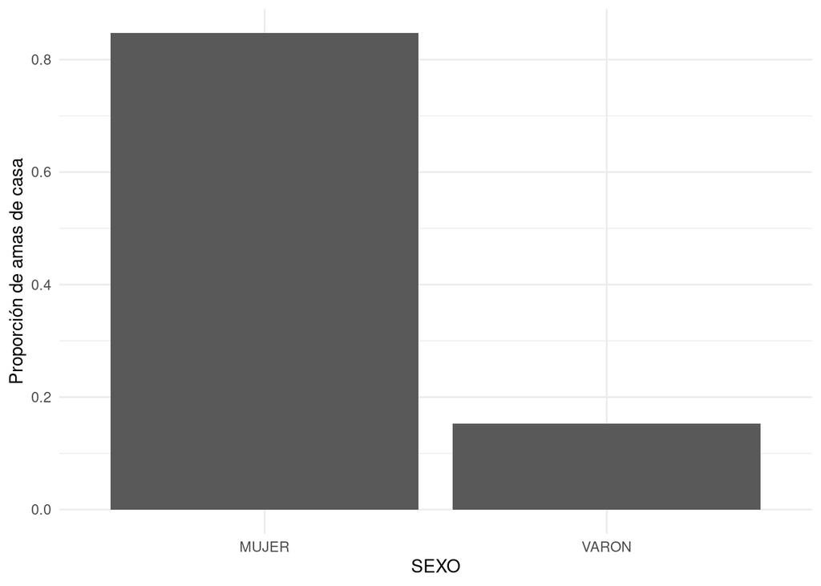

```r
df %>%
  group_by(SEXO) %>%
  summarise('N' = sum(PONDIH)) %>%
  mutate('f' = N/sum(N)) %>%
  ggplot(aes(x=SEXO,y=f)) +
  geom_bar(stat='identity') +
  scale_y_continuous(name = 'Proporción de amas de casa') +
  theme_minimal()
```

Calculando el total de personas en la misma situación usando PONDIH, tenemos un 85% de mujeres y un 15% de varones en situación AMA DE CASA

###### División por región

```r
df %>%
  group_by(REGION) %>%
  summarise('N' = sum(PONDIH)) %>%
  mutate('f' = N/sum(N))
```

```
## # A tibble: 6 × 3
##   REGION          N      f
##   <chr>       <dbl>  <dbl>
## 1 CUYO       101720 0.0536
## 2 GBA       1032873 0.544
## 3 NEA        105240 0.0555
## 4 NOA        182349 0.0961
## 5 PAMPEANA   389464 0.205
## 6 PATAGONIA   86129 0.0454
```

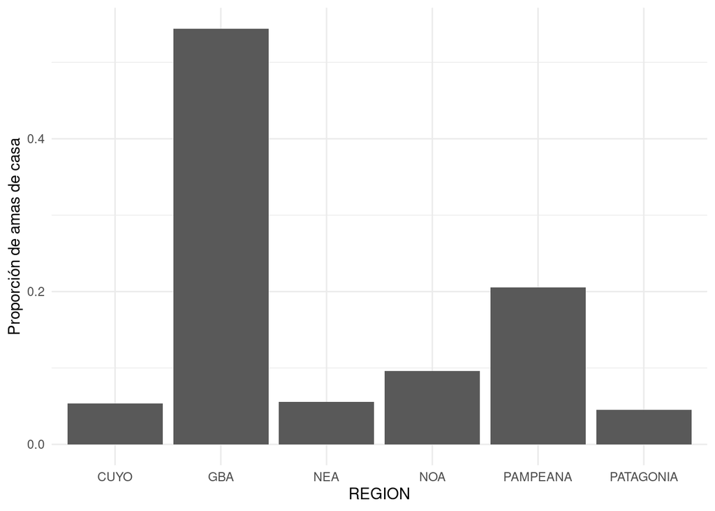

```r
df %>%
  group_by(REGION) %>%
  summarise('N' = sum(PONDIH)) %>%
  mutate('f' = N/sum(N)) %>%
  ggplot(aes(x=REGION,y=f)) +
  geom_bar(stat='identity') +
  scale_y_continuous(name = 'Proporción de amas de casa') +
  theme_minimal()
```

El grueso de las personas provienen de GBA (no muy asombroso).

```r
df %>%
  group_by(REGION,SEXO) %>%
  summarise('N' = sum(PONDIH)) %>%
  mutate('f' = N/sum(N))
```

```
## # A tibble: 12 × 4
## # Groups:   REGION [6]
##    REGION    SEXO       N      f
##    <chr>     <chr>  <dbl>  <dbl>
##  1 CUYO      MUJER  91205 0.897
##  2 CUYO      VARON  10515 0.103
##  3 GBA       MUJER 841186 0.814
##  4 GBA       VARON 191687 0.186
##  5 NEA       MUJER  94894 0.902
##  6 NEA       VARON  10346 0.0983
##  7 NOA       MUJER 160379 0.880
##  8 NOA       VARON  21970 0.120
##  9 PAMPEANA  MUJER 346229 0.889
## 10 PAMPEANA  VARON  43235 0.111
## 11 PATAGONIA MUJER  74763 0.868
## 12 PATAGONIA VARON  11366 0.132
```

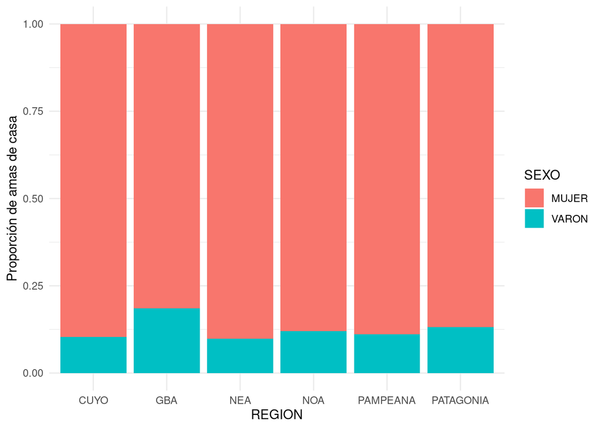

```r
df %>%
  group_by(REGION,SEXO) %>%
  summarise('N' = sum(PONDIH)) %>%
  mutate('f' = N/sum(N)) %>%
  ggplot(aes(x=REGION,y=f,fill=SEXO)) +
  geom_bar(stat='identity') +
  scale_y_continuous(name = 'Proporción de amas de casa') +
  theme_minimal()
```

El porcentaje de AMAS DE CASA mujeres varía entre el 81% (GBA) y el 90% (NEA)

# Separación por situación económica

```r
df %>%
  group_by(situacion) %>%
  summarise('N' = sum(PONDIH)) %>%
  mutate('f' = N/sum(N))
```

```
## # A tibble: 3 × 3
##   situacion      N     f
##   <chr>      <dbl> <dbl>
## 1 indigente 345425 0.182
## 2 no_pobre  816294 0.430
## 3 pobre     736056 0.388
```

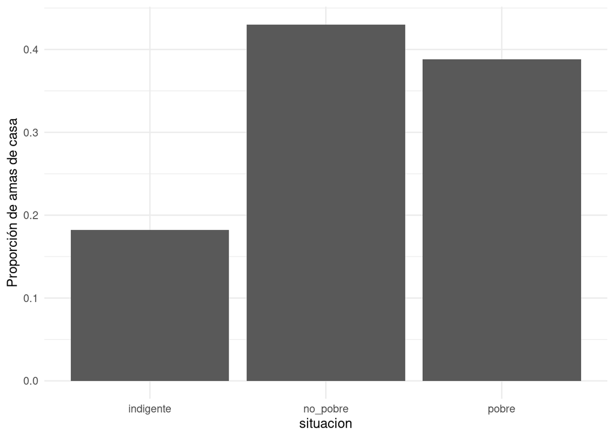

```r
df %>%
  group_by(situacion) %>%
  summarise('N' = sum(PONDIH)) %>%
  mutate('f' = N/sum(N)) %>%
  ggplot(aes(x=situacion,y=f)) +
  geom_bar(stat='identity') +
  scale_y_continuous(name = 'Proporción de amas de casa') +
  theme_minimal()
```

El 43% de las AMAS DE CASA no son pobres, el 38% son pobres, de los cuales el 18% es indigente. Vale recordar que estas definiciones representan: INDIGENTE -> ingreso familiar menor a canasta básica alimentaria, POBRE -> ingreso familiar entre canasta alimentaria y canasta total. No pobre por encima de ambas canastas.

Si separamos por género:

```r
df %>%
  group_by(situacion,SEXO) %>%
  summarise('N' = sum(PONDIH)) %>%
  mutate('f' = N/sum(N))
```

```
## # A tibble: 6 × 4
## # Groups:   situacion [3]
##   situacion SEXO       N     f
##   <chr>     <chr>  <dbl> <dbl>
## 1 indigente MUJER 239172 0.692
## 2 indigente VARON 106253 0.308
## 3 no_pobre  MUJER 722751 0.885
## 4 no_pobre  VARON  93543 0.115
## 5 pobre     MUJER 646733 0.879
## 6 pobre     VARON  89323 0.121
```

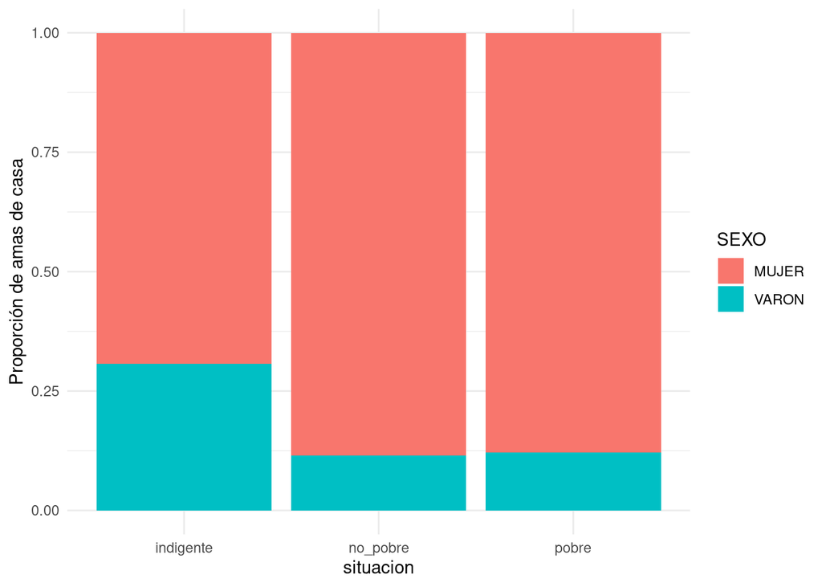

```r
df %>%
  group_by(situacion,SEXO) %>%
  summarise('N' = sum(PONDIH)) %>%
  mutate('f' = N/sum(N)) %>%
  ggplot(aes(x=situacion,y=f,fill=SEXO)) +
  geom_bar(stat='identity') +
  scale_y_continuous(name = 'Proporción de amas de casa') +
  theme_minimal()
```

```r
df %>%
  group_by(SEXO,situacion) %>%
  summarise('N' = sum(PONDIH)) %>%
  mutate('f' = N/sum(N))
```

```
## # A tibble: 6 × 4
## # Groups:   SEXO [2]
##   SEXO  situacion      N     f
##   <chr> <chr>      <dbl> <dbl>
## 1 MUJER indigente 239172 0.149
## 2 MUJER no_pobre  722751 0.449
## 3 MUJER pobre     646733 0.402
## 4 VARON indigente 106253 0.368
## 5 VARON no_pobre   93543 0.324
## 6 VARON pobre      89323 0.309
```

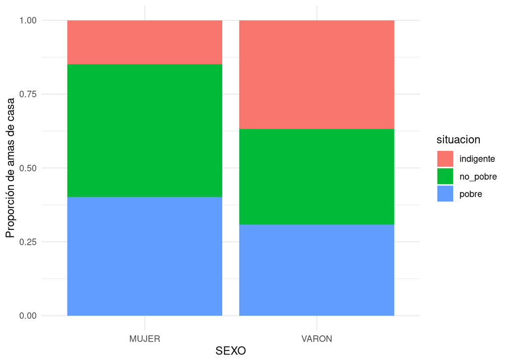

```r
df %>%
  group_by(SEXO,situacion) %>%
  summarise('N' = sum(PONDIH)) %>%
  mutate('f' = N/sum(N)) %>%
  ggplot(aes(x=SEXO,y=f,fill=situacion)) +
  geom_bar(stat='identity') +
  scale_y_continuous(name = 'Proporción de amas de casa') +
  theme_minimal()
```

A partir de estos dos gráficos podemos formular las siguientes afirmaciones, siempre condicionales a que la persona es AMA DE CASA

- Siempre es más probable ser mujer, aunque la probabilidad pasa de ser un 90-10 en pobres y no pobres, a un 70-30.
- Si se es AMA DE CASA y VARON, lo más probable es ser INDIGENTE (36%), seguido de cerca por no pobre (32%) y pobre (30%). Si se es MUJER y AMA DE CASA lo más probable es no ser pobre (45%) seguido de cerca por pobre (40%), mientras que indigente baja a 15%.

En la población indigente es más común encontrar AMAS DE CASA varones (30% contra 12%)

# Separación por EP

## Separación por EPJ

```r
df %>%
  group_by(ES_EP_JEFE) %>%
  summarise('N' = sum(PONDIH)) %>%
  mutate('f' = N/sum(N))
```

```
## # A tibble: 2 × 3
##   ES_EP_JEFE       N     f
##   <lgl>        <dbl> <dbl>
## 1 FALSE      1697101 0.894
## 2 TRUE        200674 0.106
```

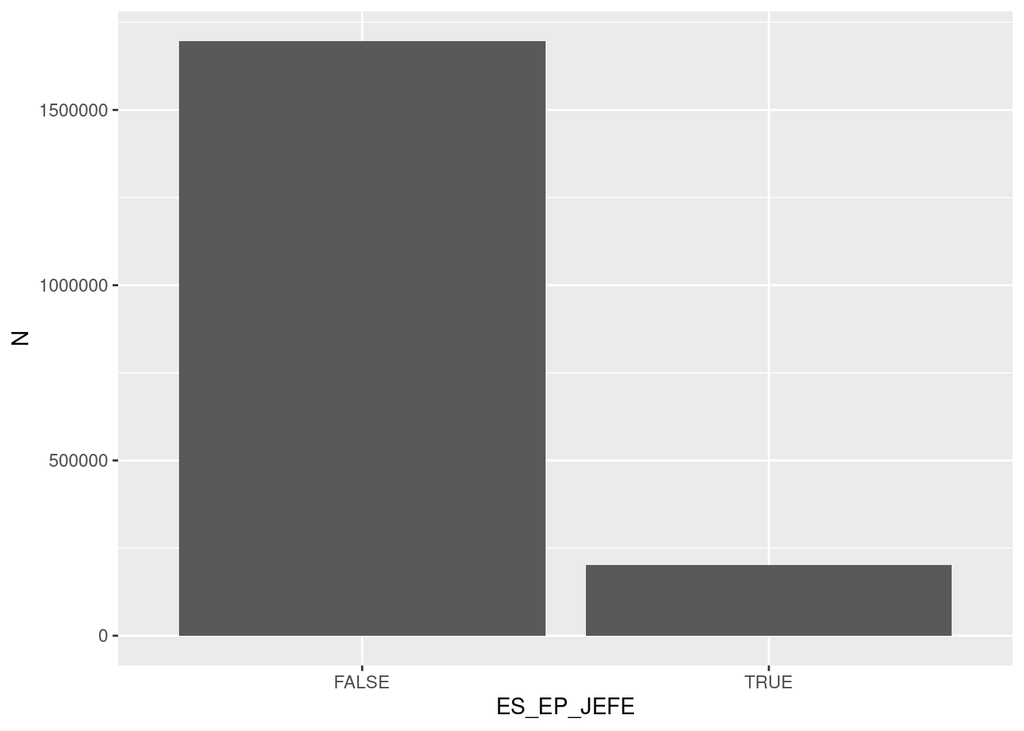

```r
df %>%
  group_by(ES_EP_JEFE) %>%
  summarise('N' = sum(PONDIH)) %>%
  mutate('f' = N/sum(N)) %>%
  ggplot(aes(x=ES_EP_JEFE,y=N)) +
  geom_bar(stat='identity')
```

Solo el 11% de las AMAS DE CASA pertenecen a hogares donde la persona en jefe es EP.

Veamos como se combina esta categoría con la categoría económica y de género

```r
df %>%
  group_by(ES_EP_JEFE,SEXO) %>%
  summarise('N' = sum(PONDIH)) %>%
  mutate('f' = N/sum(N))
```

```
## # A tibble: 4 × 4
## # Groups:   ES_EP_JEFE [2]
##   ES_EP_JEFE SEXO        N      f
##   <lgl>      <chr>   <dbl>  <dbl>
## 1 FALSE      MUJER 1427173 0.841
## 2 FALSE      VARON  269928 0.159
## 3 TRUE       MUJER  181483 0.904
## 4 TRUE       VARON   19191 0.0956
```

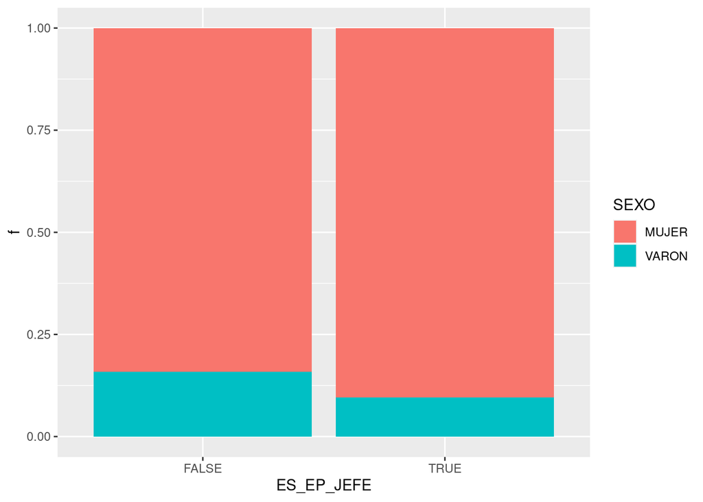

```r
df %>%
  group_by(ES_EP_JEFE,SEXO) %>%
  summarise('N' = sum(PONDIH)) %>%
  mutate('f' = N/sum(N)) %>%
  ggplot(aes(x=ES_EP_JEFE,y=f,fill=SEXO)) +
  geom_bar(stat='identity')
```

La probabilidad de que el AMA DE CASA sea MUJER aumenta de 84% a 90% de hogares sin jefe EP a hogares con jefe EP (es decir, es más común ser mujer ama de casa si el jefe es EP).

```r
df %>%
  group_by(ES_EP_JEFE,situacion) %>%
  summarise('N' = sum(PONDIH)) %>%
  mutate('f' = N/sum(N))
```

```
## # A tibble: 6 × 4
## # Groups:   ES_EP_JEFE [2]
##   ES_EP_JEFE situacion      N     f
##   <lgl>      <chr>      <dbl> <dbl>
## 1 FALSE      indigente 308134 0.182
## 2 FALSE      no_pobre  748725 0.441
## 3 FALSE      pobre     640242 0.377
## 4 TRUE       indigente  37291 0.186
## 5 TRUE       no_pobre   67569 0.337
## 6 TRUE       pobre      95814 0.477
```

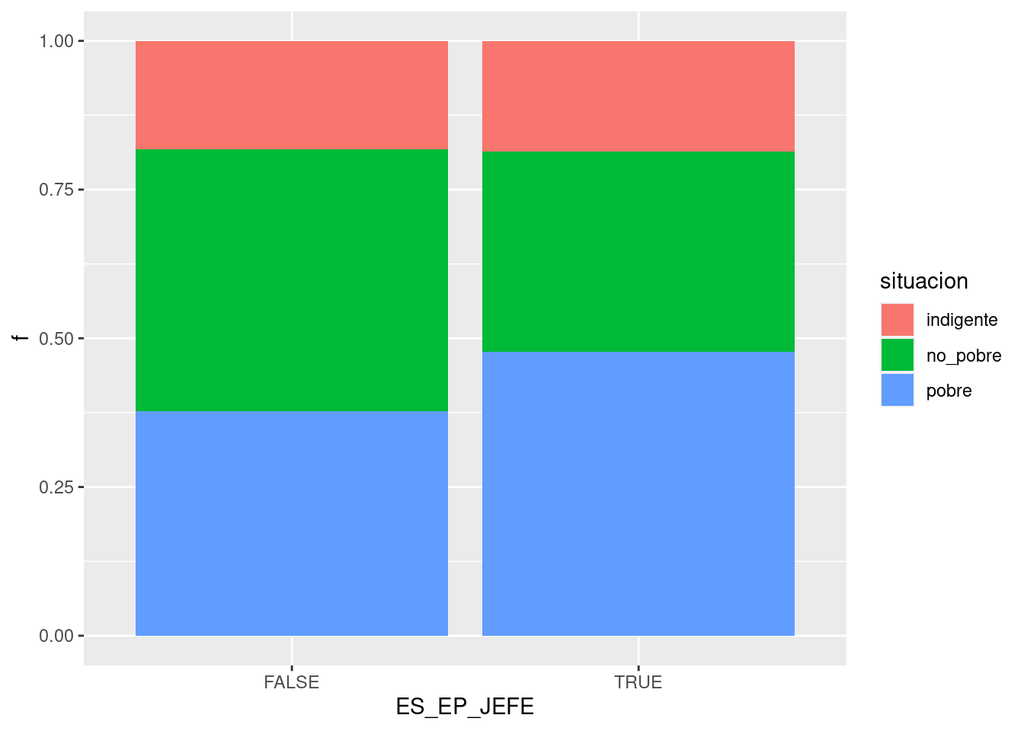

```r
df %>%
  group_by(ES_EP_JEFE,situacion) %>%
  summarise('N' = sum(PONDIH)) %>%
  mutate('f' = N/sum(N)) %>%
  ggplot(aes(x=ES_EP_JEFE,y=f,fill=situacion)) +
  geom_bar(stat='identity')
```

```r
df %>%
  group_by(situacion,ES_EP_JEFE) %>%
  summarise('N' = sum(PONDIH)) %>%
  mutate('f' = N/sum(N))
```

```
## # A tibble: 6 × 4
## # Groups:   situacion [3]
##   situacion ES_EP_JEFE      N      f
##   <chr>     <lgl>       <dbl>  <dbl>
## 1 indigente FALSE      308134 0.892
## 2 indigente TRUE        37291 0.108
## 3 no_pobre  FALSE      748725 0.917
## 4 no_pobre  TRUE        67569 0.0828
## 5 pobre     FALSE      640242 0.870
## 6 pobre     TRUE        95814 0.130
```

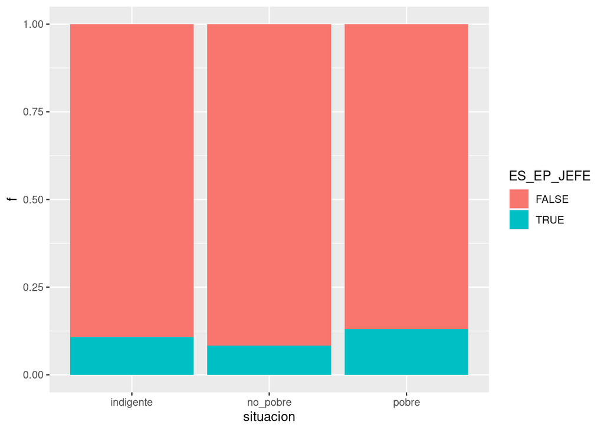

```r
df %>%
  group_by(situacion,ES_EP_JEFE) %>%
  summarise('N' = sum(PONDIH)) %>%
  mutate('f' = N/sum(N)) %>%
  ggplot(aes(x=situacion,y=f,fill=ES_EP_JEFE)) +
  geom_bar(stat='identity')
```